# Análise Discriminante Múltipla

Felipe N. S. Bezerra

10 de dezembro de 2018

Avaliação - Estatística Multivariada IV Análise Discriminante Múltipla

Considere o conjunto Auto data do pacote ISLR do software R para desenvolver um modelo de predição para prever se um carro tem alta ou baixa quilometragem.

```r
library(ISLR)
library(foreign)
library(MASS)
library(dplyr)
library(biotools)
```

```r
library(DiscriMiner)
library(ggplot2)
library(mvnormtest)
```

```r
summary(Auto)
```

```
##       mpg          cylinders      displacement     horsepower
##  Min.   : 9.00   Min.   :3.000   Min.   : 68.0   Min.   : 46.0
##  1st Qu.:17.00   1st Qu.:4.000   1st Qu.:105.0   1st Qu.: 75.0
##  Median :22.75   Median :4.000   Median :151.0   Median : 93.5
##  Mean   :23.45   Mean   :5.472   Mean   :194.4   Mean   :104.5
##  3rd Qu.:29.00   3rd Qu.:8.000   3rd Qu.:275.8   3rd Qu.:126.0
##  Max.   :46.60   Max.   :8.000   Max.   :455.0   Max.   :230.0
##
##      weight      acceleration        year           origin
##  Min.   :1613   Min.   : 8.00   Min.   :70.00   Min.   :1.000
##  1st Qu.:2225   1st Qu.:13.78   1st Qu.:73.00   1st Qu.:1.000
##  Median :2804   Median :15.50   Median :76.00   Median :1.000
##  Mean   :2978   Mean   :15.54   Mean   :75.98   Mean   :1.577
##  3rd Qu.:3615   3rd Qu.:17.02   3rd Qu.:79.00   3rd Qu.:2.000
##  Max.   :5140   Max.   :24.80   Max.   :82.00   Max.   :3.000
##
##                  name
##  amc matador       :  5
##  ford pinto        :  5
##  toyota corolla    :  5
##  amc gremlin       :  4
##  amc hornet        :  4
##  chevrolet chevette:  4
##  (Other)           :365
```

```
(a) Crie uma variável binária, classmpg, que seja igual a 1 se o mpg for maior do que a mediana e 0, caso contrário. Você pode calcular a mediana de mpg no R usando a função median(). Note que talvez seja mais fácil usar o comando data.frame() para criar um conjunto de dados que contenha o classmpg …
```

```r
avaldata <- Auto[,-1]
avaldata <- avaldata[,-8]
avaldata$origin <- as.factor(avaldata$origin)

scaleavaldata <- avaldata[,-7]
scaleavaldata <- as.data.frame(scale(scaleavaldata))

classmpg <- as.numeric(Auto$mpg>median(Auto$mpg))
avaldata$classmpg <- as.factor(classmpg)
scaleavaldata$origin <- avaldata$origin
scaleavaldata$classmpg <- avaldata$classmpg
```

```
(b) Explore os dados graficamente para investigar a associação entre o classmpg e as demais variáveis. Quais variáveis parecem ser úteis para prever o classmpg? Pode usar boxplots para responder a essa questão.
```

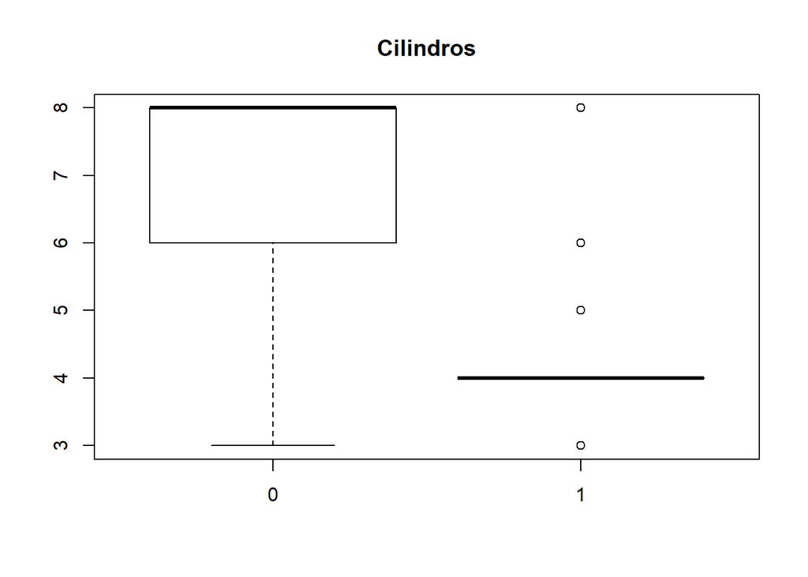

```r
boxplot(avaldata$cylinders ~ avaldata$classmpg, main='Cilindros')
```

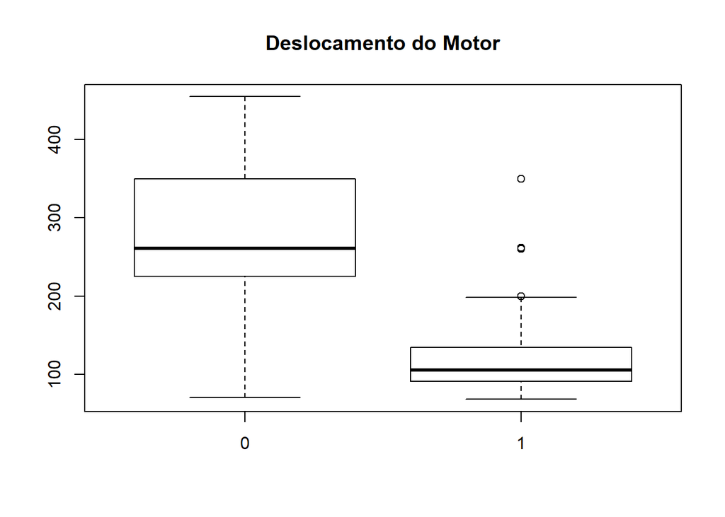

```r
boxplot(avaldata$displacement ~ avaldata$classmpg, main='Deslocamento do Motor')
```

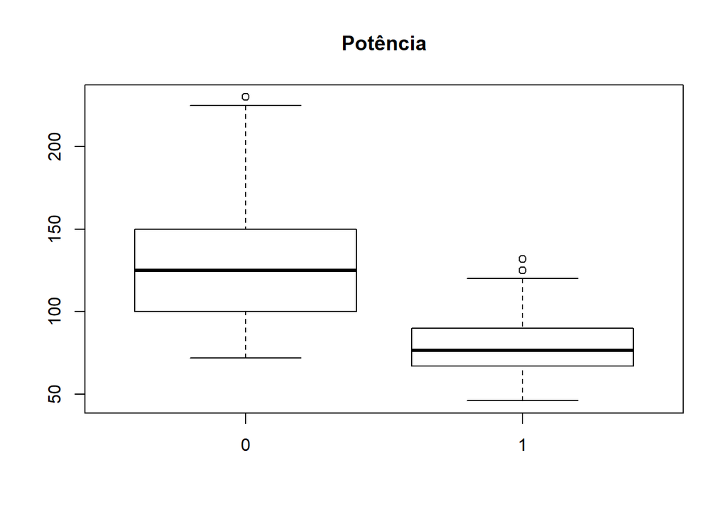

```r
boxplot(avaldata$horsepower ~ avaldata$classmpg, main='Potência')
```

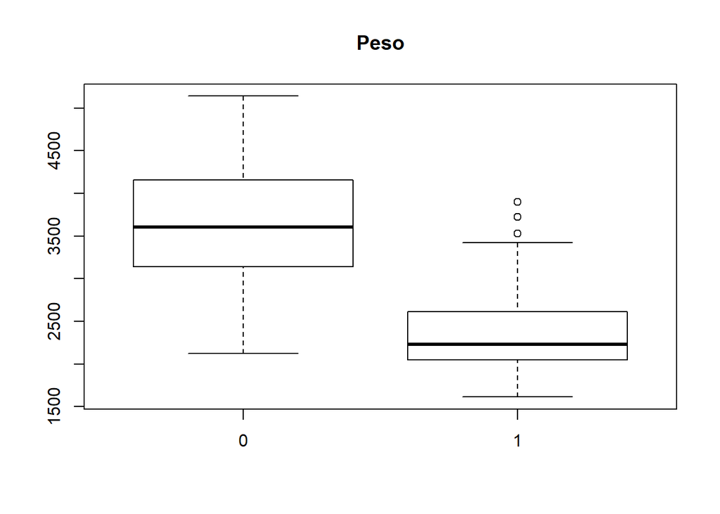

```r
boxplot(avaldata$weight ~ avaldata$classmpg, main='Peso')
```

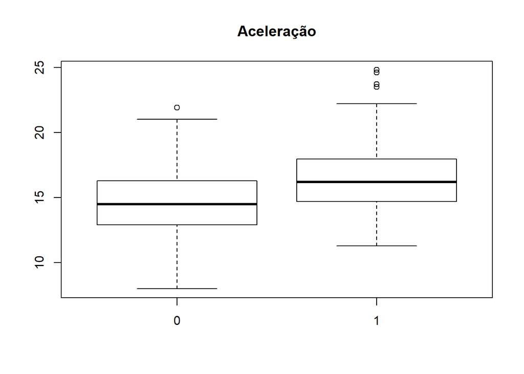

```r
boxplot(avaldata$acceleration ~ avaldata$classmpg, main='Aceleração')
```

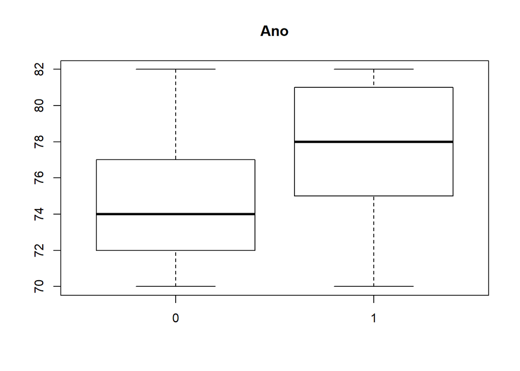

```r
boxplot(avaldata$year ~ avaldata$classmpg, main='Ano')
```

```r
aggregate(avaldata[,1:6], list(avaldata$classmpg), quantile)
```

[output not shown]

As variáveis “Cilindros” e “Deslocamento do Motor” parecem possuir maior acertividade em definir os veículos com maior consumo de combustível (classmpg = 0). Veículos com um número de cilindros diferente de 4 e Deslocamento do Motor com mais de 200 in percorrem menos milhas por galão; as demais faixas destas variáveis apresentam consumo de combustível variado. Veículos com maior potência, menor aceleração, mais pesados e mais antigos aparentam consumir mais combustível, mas tendência não se mostra tão definida quanto as duas variáveis citadas anteriormente.

```
(c) Divida os dados em duas amostras, uma de treino (75%) e outra de teste (25%).
```

```r
set.seed(8)
treinoaval <- scaleavaldata[sample(nrow(scaleavaldata),  size = nrow(scaleavaldata) * 0.75),]
testeaval <- scaleavaldata[-sample(nrow(scaleavaldata),  size = nrow(scaleavaldata) * 0.75),]
```

```
(d) Obtenha e interprete as funções discriminantes para esse estudo. Verifique também as suposições da análise. Você utilizaria a análise discriminante linear ou quadrática para classificação?
```

Verificação do tamanho da amostra:

```r
table(scaleavaldata$classmpg)
```

```
##
##   0   1
## 196 196
```

```r
table(treinoaval$classmpg)
```

```
##
##   0   1
## 146 148
```

```r
table(testeaval$classmpg)
```

```
##
##  0  1
## 50 48
```

Todos os grupos possuem mais de 20 observações (número aceitável para 6 variáveis independentes), inclusive nas amostras separadas para treino e teste.

Verificação de multicolinearidade:

```r
cor(scaleavaldata[,1:6])
```

```
##               cylinders displacement horsepower     weight acceleration
## cylinders     1.0000000    0.9508233  0.8429834  0.8975273   -0.5046834
## displacement  0.9508233    1.0000000  0.8972570  0.9329944   -0.5438005
## horsepower    0.8429834    0.8972570  1.0000000  0.8645377   -0.6891955
## weight        0.8975273    0.9329944  0.8645377  1.0000000   -0.4168392
## acceleration -0.5046834   -0.5438005 -0.6891955 -0.4168392    1.0000000
## year         -0.3456474   -0.3698552 -0.4163615 -0.3091199    0.2903161
##                    year
## cylinders    -0.3456474
## displacement -0.3698552
## horsepower   -0.4163615
## weight       -0.3091199
## acceleration  0.2903161
## year          1.0000000
```

As variáveis “Cilindros”e “Deslocamento do Motor” estão altamente correlacionadas (correlação superior a 0,95). Utilizar ambas implica em redundância, então apenas uma (Deslocamento do Motor) será utilizada no ajuste do modelo.

Normalidade multivariada das variáveis independentes:

```r
mshapiro.test(t(scaleavaldata[,1:6]))
```

```
##
##  Shapiro-Wilk normality test
##
## data:  Z
## W = 0.86677, p-value < 2.2e-16
```

```r
shapiro.test(scaleavaldata$cylinders)
```

```
##
##  Shapiro-Wilk normality test
##
## data:  scaleavaldata$cylinders
## W = 0.75066, p-value < 2.2e-16
```

```r
shapiro.test(scaleavaldata$displacement)
```

```
##
##  Shapiro-Wilk normality test
##
## data:  scaleavaldata$displacement
## W = 0.88184, p-value < 2.2e-16
```

```r
shapiro.test(scaleavaldata$horsepower)
```

```
##
##  Shapiro-Wilk normality test
##
## data:  scaleavaldata$horsepower
## W = 0.9041, p-value = 5.022e-15
```

```r
shapiro.test(scaleavaldata$weight)
```

```
##
##  Shapiro-Wilk normality test
##
## data:  scaleavaldata$weight
## W = 0.94147, p-value = 2.602e-11
```

```r
shapiro.test(scaleavaldata$acceleration)
```

```
##
##  Shapiro-Wilk normality test
##
## data:  scaleavaldata$acceleration
## W = 0.99187, p-value = 0.03053
```

```r
shapiro.test(scaleavaldata$year)
```

```
##
##  Shapiro-Wilk normality test
##
## data:  scaleavaldata$year
## W = 0.94697, p-value = 1.223e-10
```

Segundo o teste de Shapiro-Wilk, nenhuma das variáveis independentes segue distribuição normal e, consequentemente, a amostra não obedece ao pressuposto de normalidade multivariada, requerido para que se prossiga com a análise discriminante.

Homogeneidade de variância/covariância:

```r
boxM(data = scaleavaldata[,1:6], grouping = scaleavaldata$classmpg)
```

```
##
##  Box's M-test for Homogeneity of Covariance Matrices
##
## data:  scaleavaldata[, 1:6]
## Chi-Sq (approx.) = 404.08, df = 21, p-value < 2.2e-16
```

Não há igualdade entre as matrizes de variâncias e covariâncias da amostra, mesmo considerando aceitável um p-valor de 0,01 (mais comum para este teste).

Seleção de variável:

```r
discPower(variables = treinoaval[,1:6], group = treinoaval$classmpg)
```

|  | correl_ratio | wilks_lambda | F_statistic | p_value |
| --- | --- | --- | --- | --- |
| cylinders | 0.5610599 | 0.4389401 | 373.23890 | 0.000000e+00 |
| displacement | 0.5495676 | 0.4504324 | 356.26593 | 0.000000e+00 |
| horsepower | 0.4354455 | 0.5645545 | 225.22203 | 0.000000e+00 |
| weight | 0.5725786 | 0.4274214 | 391.16648 | 0.000000e+00 |
| acceleration | 0.1017403 | 0.8982597 | 33.07302 | 2.236779e-08 |
| year | 0.1996819 | 0.8003181 | 72.85494 | 7.771561e-16 |

[output not shown]

Todas as variáveis contribuem significativamente para a discriminação dos grupos (embora com menor relevância se tratando da “Aceleração” e do “Ano do Modelo”).

Determinação da função discriminante:

```r
discrim_aval <- desDA(variables = treinoaval[, c("displacement", "horsepower", "weight", "acceleration", "year")],
                   group = treinoaval$classmpg)
```

Coeficientes das funções discriminantes:

```r
discrim_aval$discrivar
```

```
##                       DF1
## constant     -0.004868575
## displacement -0.606862514
## horsepower    0.467179185
## weight       -1.262871937
## acceleration  0.033320876
## year          0.477663363
```

Como há apenas dois grupos, só é necessária uma função discriminante. $DF= -0,005 -0,607*displacement +0,467*horsepower -1,263*weight +0,033*acceleration +0,478*year$

Autovalores das funções discriminantes e variabilidade explicada:

```r
discrim_aval$values
```

```
##        value proportion accumulated
## DF1 1.699744        100         100
```

Como só há uma função discriminante, toda a variância do modelo é explicada por ela.

Matriz de fatores (correlação entre as variáveis explicativas e a função discriminante):

```r
discrim_aval$discor
```

```
##                     DF1
## displacement -0.9342946
## horsepower   -0.8316493
## weight       -0.9536540
## acceleration  0.4019941
## year          0.5631741
```

A função discriminante obtida é mais fortemente ponderada pelo “Peso do Veídulo” e pelo “Deslocamento do motor”, e menos pela “Aceleração” e pelo “Ano do Modelo”.

Significância da função discriminante

```r
summary(aov(discrim_aval$scores ~ treinoaval$classmpg), test="Wilks")
```

```
##                      Df Sum Sq Mean Sq F value Pr(>F)
## treinoaval$classmpg   1  496.3   496.3   496.3 <2e-16 ***
## Residuals           292  292.0     1.0
## ---
## Signif. codes:  0 '***' 0.001 '**' 0.01 '*' 0.05 '.' 0.1 ' ' 1
```

Dado o baixo p-valor, a função é considerada significante.

Centróide:

```r
treinoaval$DF1 <- discrim_aval$scores
treinoaval %>% group_by(classmpg) %>% summarise(C = mean(DF1))
```

| classmpg | C |
| --- | --- |
| 0 | -1.308139 |
| 1 | 1.290461 |